# Lab 7A: Machine Learning (Easy)

### Split Data into Test and Training Set

8. Set the seed to make randomness reproducable

```r
set.seed(42)
```

9. Randomly sample 100 of 150 row indexes

```r
indexes <- sample(
    x = 1:150,
    size = 100)
```

10. Create a training set from indexes

```r
train <- iris[indexes, ]
```

11. Create a test set from remaining indexes

```r
test <- iris[-indexes, ]
```

### Predict using Decision Tree

12. Load the decision tree package

```r
library(tree)
```

13. Train tree model

```r
treeModel <- tree(
    formula = Species ~ .,
    data = train)
```

14. Inspect the model

```r
summary(treeModel)
```

```
##
## Classification tree:
## tree(formula = Species ~ ., data = train)
## Variables actually used in tree construction:
## [1] "Petal.Length" "Petal.Width"
## Number of terminal nodes:  4
## Residual mean deviance:  0.05213 = 5.004 / 96
## Misclassification error rate: 0.01 = 1 / 100
```

15. Plot the model

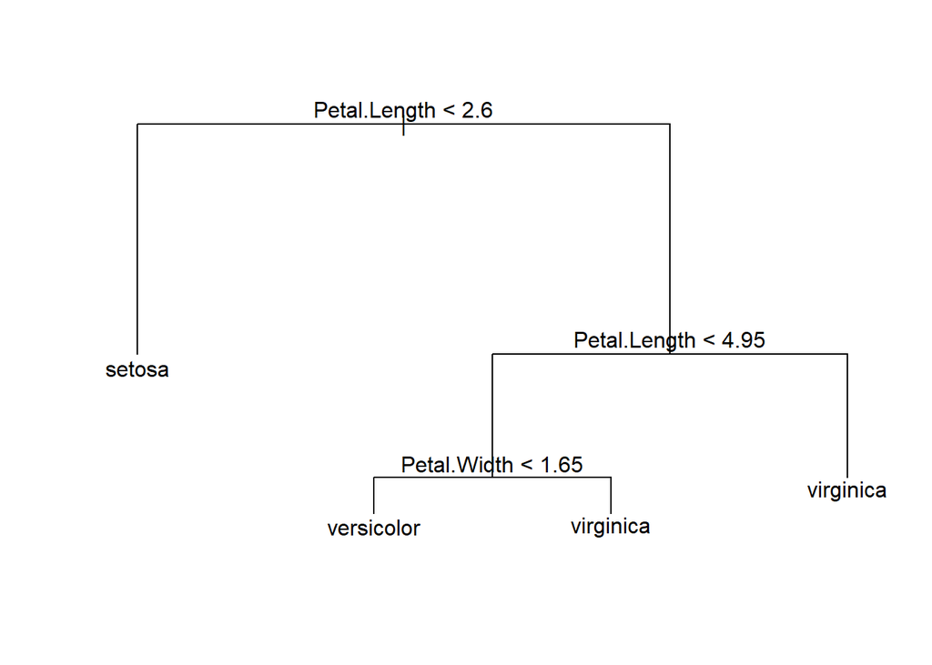

```r
plot(treeModel)
text(treeModel)
```

16. Plot the decision boundaries

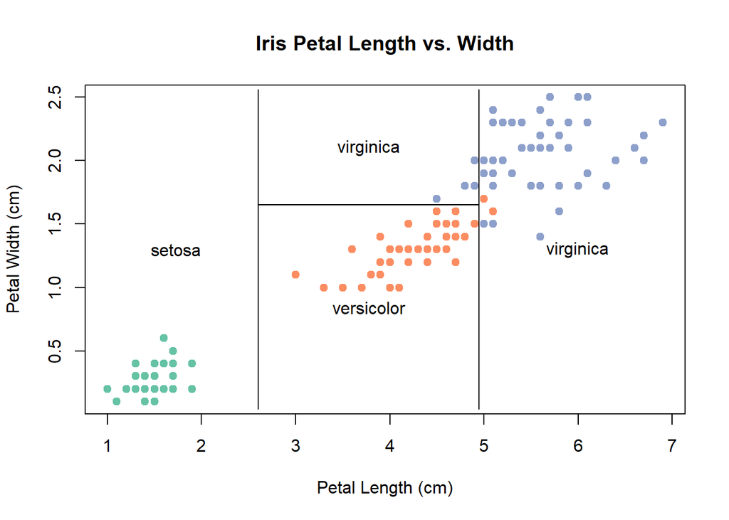

```r
plot(
    x = iris$Petal.Length,
    y = iris$Petal.Width,
    pch = 19,
    col = palette[as.numeric(iris$Species)],
    main = "Iris Petal Length vs. Width",
    xlab = "Petal Length (cm)",
    ylab = "Petal Width (cm)")

partition.tree(
    tree = treeModel,
    label = "Species",
    add = TRUE)
```

17. Predict with the model

```r
treePredictions <- predict(
    object = treeModel,
    newdata = test,
    type = "class")
```

18. Inspect the prediction accuracy

```r
table(
    x = treePredictions,
    y = test$Species)
```

```
##             y
## x            setosa versicolor virginica
##   setosa         17          0         0
##   versicolor      0         16         0
##   virginica       0          2        15
```

19. Load the caret package

```r
library(caret)
```

20. Evaluate the prediction results

```r
confusionMatrix(
    data = treePredictions,
    reference = test$Species)
```

```
## Confusion Matrix and Statistics
##
##             Reference
## Prediction   setosa versicolor virginica
##   setosa         17          0         0
##   versicolor      0         16         0
##   virginica       0          2        15
##
## Overall Statistics
##
##                Accuracy : 0.96
##                  95% CI : (0.8629, 0.9951)
##     No Information Rate : 0.36
##     P-Value [Acc > NIR] : < 2.2e-16
##
##                   Kappa : 0.94
##  Mcnemar's Test P-Value : NA
##
## Statistics by Class:
##
##                      Class: setosa Class: versicolor Class: virginica
## Sensitivity                   1.00            0.8889           1.0000
## Specificity                   1.00            1.0000           0.9429
## Pos Pred Value                1.00            1.0000           0.8824
## Neg Pred Value                1.00            0.9412           1.0000
## Prevalence                    0.34            0.3600           0.3000
## Detection Rate                0.34            0.3200           0.3000
## Detection Prevalence          0.34            0.3200           0.3400
## Balanced Accuracy             1.00            0.9444           0.9714
```

### Predict using Naive Bayes Classifier

21. Load the e1071 package

```r
library(e1071)
```

22. Train the model

```r
bayesModel <- naiveBayes(
    formula = Species ~ .,
    data = train)
```

23. Inspect the model

```r
summary(bayesModel)
```

```
##         Length Class  Mode
## apriori 3      table  numeric
## tables  4      -none- list
## levels  3      -none- character
## call    4      -none- call
```

24. Predict with the model

```r
bayesPredictions <- predict(
    object = bayesModel,
    newdata = test[, 1:4])
```

25. Evaluate the prediction results

```r
confusionMatrix(
    data = bayesPredictions,
    reference = test$Species)
```

```
## Confusion Matrix and Statistics
##
##             Reference
## Prediction   setosa versicolor virginica
##   setosa         17          0         0
##   versicolor      0         16         1
##   virginica       0          2        14
##
## Overall Statistics
##
##                Accuracy : 0.94
##                  95% CI : (0.8345, 0.9875)
##     No Information Rate : 0.36
##     P-Value [Acc > NIR] : < 2.2e-16
##
##                   Kappa : 0.9099
##  Mcnemar's Test P-Value : NA
##
## Statistics by Class:
##
##                      Class: setosa Class: versicolor Class: virginica
## Sensitivity                   1.00            0.8889           0.9333
## Specificity                   1.00            0.9688           0.9429
## Pos Pred Value                1.00            0.9412           0.8750
## Neg Pred Value                1.00            0.9394           0.9706
## Prevalence                    0.34            0.3600           0.3000
## Detection Rate                0.34            0.3200           0.2800
## Detection Prevalence          0.34            0.3400           0.3200
## Balanced Accuracy             1.00            0.9288           0.9381
```

### Predict with Neural Network

26. Load the Neural Network package

```r
library(nnet)
```

27. Train the model

```r
neuralModel <- nnet(
    formula = Species ~ .,
    data = train,
    size = 4,
    decay = 0.0001,
    maxit = 500)
```

28. Inspect the model

```r
summary(neuralModel)
```

```
## a 4-4-3 network with 35 weights
## options were - softmax modelling  decay=1e-04
##  b->h1 i1->h1 i2->h1 i3->h1 i4->h1
##  -1.88  -6.20  12.82   1.37   0.09
##  b->h2 i1->h2 i2->h2 i3->h2 i4->h2
##   6.61   5.95   8.32 -10.54  -9.20
##  b->h3 i1->h3 i2->h3 i3->h3 i4->h3
##   0.42   0.92   1.12  -2.72  -1.33
##  b->h4 i1->h4 i2->h4 i3->h4 i4->h4
##  -0.41  -0.81  -1.10   2.40   1.15
##  b->o1 h1->o1 h2->o1 h3->o1 h4->o1
##   0.43   0.49   2.17   6.38  -6.22
##  b->o2 h1->o2 h2->o2 h3->o2 h4->o2
##  -3.42  -9.28  17.97  -6.43   3.07
##  b->o3 h1->o3 h2->o3 h3->o3 h4->o3
##   2.98   8.78 -20.14   0.05   3.15
```

29. Load the NeuralNetTools package

```r
library(NeuralNetTools)
```

30. Visualize the neural network

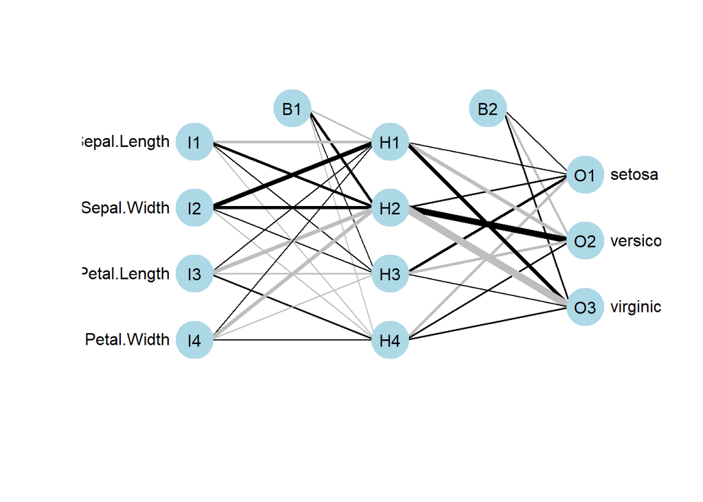

```r
plotnet(neuralModel)
```

31. Predict with the model

```r
neuralPredictions <- predict(
    object = neuralModel,
    newdata = test[, 1:4],
    type = "class")
```

32. Evaluate the prediction results

```r
confusionMatrix(
    data = neuralPredictions,
    reference = test$Species)
```

```
## Confusion Matrix and Statistics
##
##             Reference
## Prediction   setosa versicolor virginica
##   setosa         17          0         0
##   versicolor      0         17         0
##   virginica       0          1        15
##
## Overall Statistics
##
##                Accuracy : 0.98
##                  95% CI : (0.8935, 0.9995)
##     No Information Rate : 0.36
##     P-Value [Acc > NIR] : < 2.2e-16
##
##                   Kappa : 0.97
##  Mcnemar's Test P-Value : NA
##
## Statistics by Class:
##
##                      Class: setosa Class: versicolor Class: virginica
## Sensitivity                   1.00            0.9444           1.0000
## Specificity                   1.00            1.0000           0.9714
## Pos Pred Value                1.00            1.0000           0.9375
## Neg Pred Value                1.00            0.9697           1.0000
## Prevalence                    0.34            0.3600           0.3000
## Detection Rate                0.34            0.3400           0.3000
## Detection Prevalence          0.34            0.3400           0.3200
## Balanced Accuracy             1.00            0.9722           0.9857
```

33. Set working directory

```r
setwd("C:/Workshop/Data")
```

34. Save the tree model

```r
save(treeModel, file = "Tree.RData")
```